# Assigning Solve Solutions in Mathematica

This can be quite tricky, first define a system of equations:

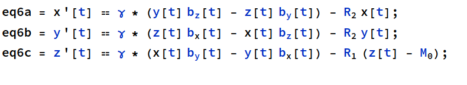

*content_copy*

```
ClearAll["Global`*"]

eq6a = x'[
    t] == g * (y[t] Subscript[b, z][t] -
       z[t] Subscript[b, y][t]) - Subscript[R, 2] x[t];
eq6b = y'[
    t] == g * (z[t] Subscript[b, x][t] -
       x[t] Subscript[b, z][t]) - Subscript[R, 2] y[t];
eq6c = z'[
    t] == \[Gamma] * (x[t] Subscript[b, y][t] -
       y[t] Subscript[b, x][t]) -
    Subscript[R, 1] (z[t] - Subscript[M, 0]);
```

Use the solve command to solve it:

*content_copy*

```
Solve[{eq6a, eq6b}, {x[t], y[t]}]
```

If that works use substitution to grab one of the variables, say $x(t)$ :

*content_copy*

```
s = First[x[t] /. Solve[{eq6a, eq6b}, {x [t], y [t]}]]
```

*content_copy*

```
xfunc[blah_] := s /. t -> blah
xfunc[t]
```

- WARNING
  - The function name, as above `xfunc[]` MUST NOT be `x[t]` otherwise there will be some sort of recursive error and *Mathematica* will time out
    - Be mindful if this occurs, it is not-sufficient to use `Alt` + `.`, or to kill the kernel from the memory, Mathematica MUST be restarted because it will behave strangely.

    So doing this all together:

*content_copy*

```
    Solve[{eq6a, eq6b}, {x [t], y [t]}];
s = First[x[t] /. Solve[{eq6a, eq6b}, {x [t], y [t]}]];
vfunc[blah_] := s /. t -> blah
vfunc[t]
```

*paperclip*Check out this Example:

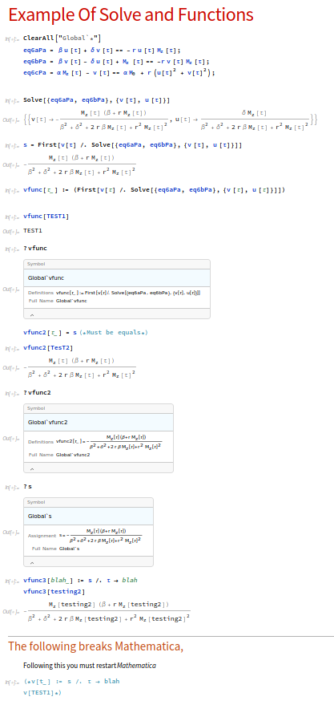